# PA1_Reproducible_Research

Mark

2023-03-28

## Step 1 - Code for reading in the dataset and/or processing the data

```r
library(readr)
activity <- read.csv("activity.csv")
head(activity)
```

```
##   steps       date interval
## 1    NA 2012-10-01        0
## 2    NA 2012-10-01        5
## 3    NA 2012-10-01       10
## 4    NA 2012-10-01       15
## 5    NA 2012-10-01       20
## 6    NA 2012-10-01       25
```

```r
tail(activity)
```

```
##       steps       date interval
## 17563    NA 2012-11-30     2330
## 17564    NA 2012-11-30     2335
## 17565    NA 2012-11-30     2340
## 17566    NA 2012-11-30     2345
## 17567    NA 2012-11-30     2350
## 17568    NA 2012-11-30     2355
```

```r
str(activity)
```

```
## 'data.frame':    17568 obs. of  3 variables:
##  $ steps   : int  NA NA NA NA NA NA NA NA NA NA ...
##  $ date    : chr  "2012-10-01" "2012-10-01" "2012-10-01" "2012-10-01" ...
##  $ interval: int  0 5 10 15 20 25 30 35 40 45 ...
```

```r
summary(activity)
```

```
##      steps            date              interval
##  Min.   :  0.00   Length:17568       Min.   :   0.0
##  1st Qu.:  0.00   Class :character   1st Qu.: 588.8
##  Median :  0.00   Mode  :character   Median :1177.5
##  Mean   : 37.38                      Mean   :1177.5
##  3rd Qu.: 12.00                      3rd Qu.:1766.2
##  Max.   :806.00                      Max.   :2355.0
##  NA's   :2304
```

## Step 2 - Histogram of the total number of steps taken each day

```r
library(dplyr)
```

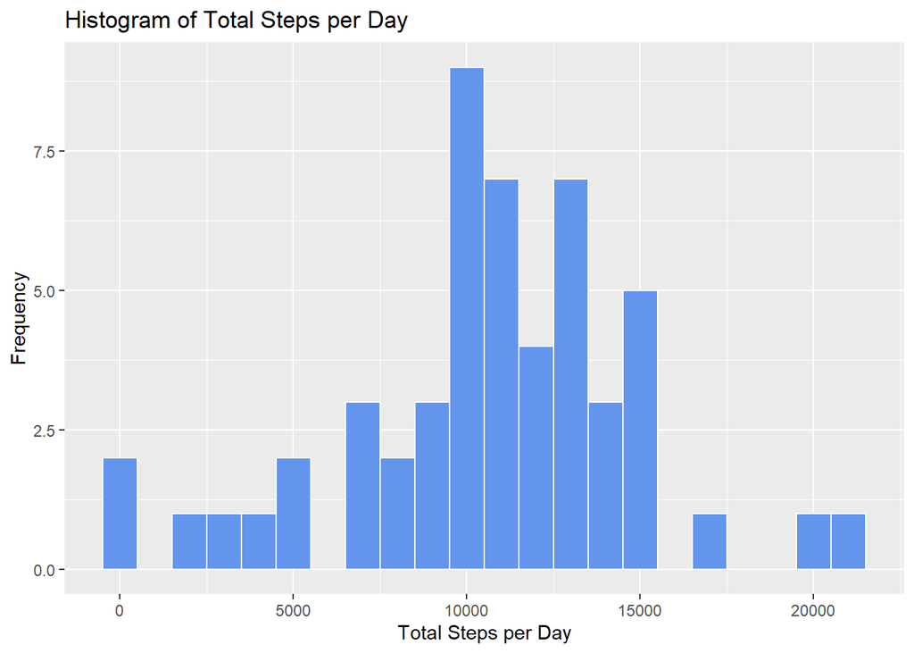

```r
library(ggplot2)
daily_sum <- activity %>% group_by(date) %>% summarise(total_steps = sum(steps), na.rm = TRUE)
ggplot(data = daily_sum, aes(x = total_steps)) +
  geom_histogram(binwidth = 1000, fill = "cornflowerblue", color = "white") +
  labs(x = "Total Steps per Day", y = "Frequency", title = "Histogram of Total Steps per Day")
```

## Step 3 - Mean and median number of steps taken each day

```r
activity %>% group_by(date) %>% summarise(mean_steps = mean(steps, na.rm = TRUE), median_steps = median(steps, na.rm = TRUE))
```

```
## # A tibble: 61 × 3
##    date       mean_steps median_steps
##    <chr>           <dbl>        <dbl>
##  1 2012-10-01    NaN               NA
##  2 2012-10-02      0.438            0
##  3 2012-10-03     39.4              0
##  4 2012-10-04     42.1              0
##  5 2012-10-05     46.2              0
##  6 2012-10-06     53.5              0
##  7 2012-10-07     38.2              0
##  8 2012-10-08    NaN               NA
##  9 2012-10-09     44.5              0
## 10 2012-10-10     34.4              0
## # … with 51 more rows
```

## Step 4 - Time series plot of the average number of steps taken

[figure not shown]

```r
mean_steps <- activity %>% group_by(date) %>% summarise(mean_steps = mean(steps, na.rm = TRUE))
ggplot(mean_steps, aes(x = date, y = mean_steps))+
    geom_bar(stat = "identity", fill = "blue") +
    labs(x = "Date", y = "Mean_Steps", title = "Time Series Mean Steps")
```

## Step 5 - The 5-minute interval that, on average, contains the maximum number of steps - transform column interval to character type - calculate the mean steps for each interval - sort the steps in descending for interval - select the first row in the data set as the maximum

```r
activity$interval <- as.character(activity$interval)
mean_interval_steps <- activity %>% group_by(interval) %>% summarise(mean_steps = mean(steps, na.rm = TRUE))
sorted_data <- mean_interval_steps %>% arrange(desc(mean_steps))
sorted_data %>% slice(1)
```

```
## # A tibble: 1 × 2
##   interval mean_steps
##   <chr>         <dbl>
## 1 835            206.
```

## Step 6 - Code to describe and show a strategy for imputing missing data

using sum to understand the number of NA in the column steps, mean() to get the % of NA calculate the mean value by group of interval and acquire a new data set merge the activity data set with the merged_activity one by the column of interval replace the NA by the mean value for respective interval group remove the mean_steps column transform the numeric type to integer for easier understanding

```r
sum(is.na(activity$steps))
```

```
## [1] 2304
```

```r
mean(is.na(activity$steps))
```

```
## [1] 0.1311475
```

```r
activity$date <- as.character(activity$date)
act_mean <- activity %>% group_by(interval) %>% summarise(step_mean = mean(steps, na.rm = TRUE))
merged_activity <- merge(activity, act_mean, by = "interval")
merged_activity$steps[is.na(merged_activity$steps)] <- merged_activity$step_mean[is.na(merged_activity$steps)]
merged_activity$step_mean <- NULL
merged_activity$steps <- as.integer(merged_activity$steps)
summary(merged_activity)
```

```
##    interval             steps            date
##  Length:17568       Min.   :  0.00   Length:17568
##  Class :character   1st Qu.:  0.00   Class :character
##  Mode  :character   Median :  0.00   Mode  :character
##                     Mean   : 37.33
##                     3rd Qu.: 27.00
##                     Max.   :806.00
```

## Step 7 - Histogram of the total number of steps taken each day after missing values are imputed

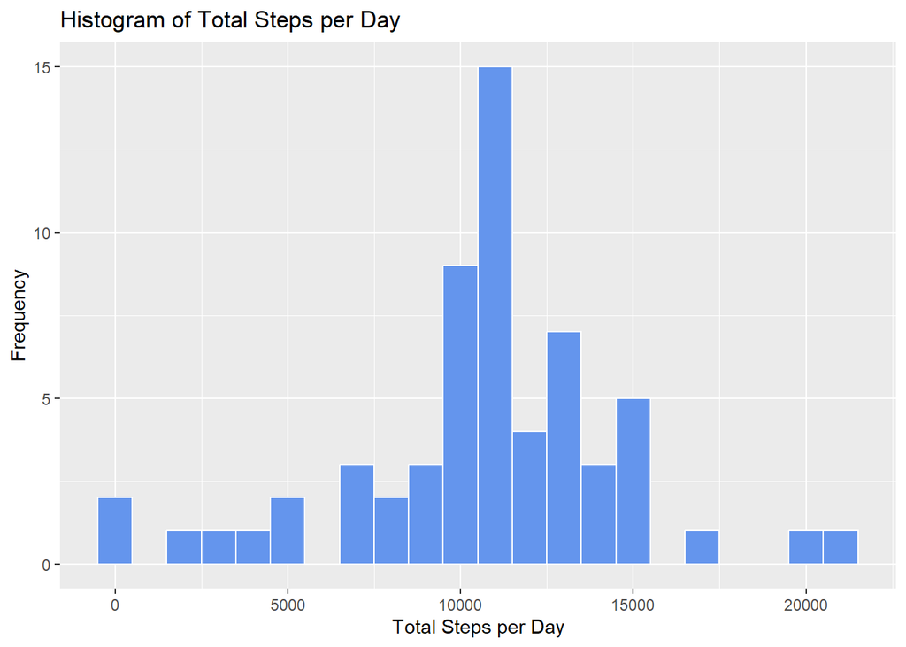

```r
daily_sum_2 <- merged_activity %>% group_by(date) %>% summarise(total_steps = sum(steps), na.rm = TRUE)
ggplot(data = daily_sum_2, aes(x = total_steps)) +
  geom_histogram(binwidth = 1000, fill = "cornflowerblue", color = "white") +
  labs(x = "Total Steps per Day", y = "Frequency", title = "Histogram of Total Steps per Day")
```

## Step 8 - Panel plot comparing the average number of steps taken per 5-minute interval across weekdays and weekends

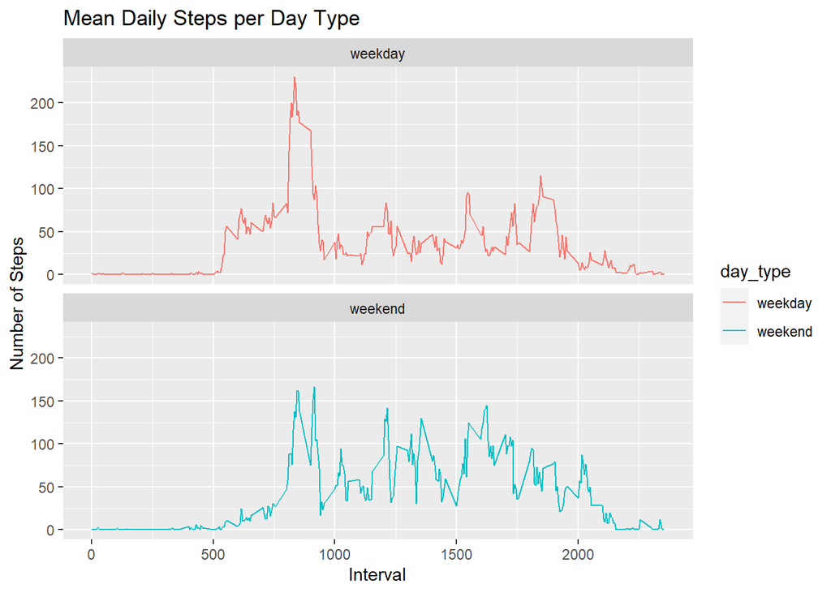

```r
merged_activity$date <- as.Date(merged_activity$date)
merged_activity$day_type <- ifelse(weekdays(merged_activity$date) %in% c("Saturday", "Sunday"), "weekend", "weekday")
merged_activity$day_type <- factor(merged_activity$day_type, levels = c("weekday", "weekend"))
steps_day_type <-  aggregate(steps ~ interval + day_type, merged_activity, mean)
steps_day_type$interval <- as.integer(steps_day_type$interval)
ggplot(steps_day_type, aes(interval, steps, color = day_type)) +
  geom_line() + ggtitle("Mean Daily Steps per Day Type") +
  xlab("Interval") +
  ylab("Number of Steps") +
  facet_wrap(.~day_type, ncol=1,nrow=2)
```